# 07. Presenting Results

## Labels and themes

We have seen a number of ways to create and modify data visualizations. One thing that we did not cover was how to label our axes. While many data visualization guides like to stress the importance of labelling axes, while in the exploratory phase of analysis it is often best to simply use the default labels provided by R. These are useful for a number of reasons. First, they require minimal effort and make it easy to tweak axes, variables, and other settings without spending time tweaking with the labels. Secondly, the default labels use the variable names in our dataset. When writing code this is *exactly* what we need to know about a variable to use it in additional plots, models, and data manipulation tasks. Of course, once we want to present our results to others, it is essential to provide more detailed descriptions of the axes and legends in our plot. Fortunately, this is relatively easy using the grammar of graphics.

In order to change the labels in a plot, we can use the `labs` function as an extra part of our plot. Inside the function, we assign labels to the names of aes values that you want to describe. Leaving a value unspecified will keep the default value in place. Labels for the x-axis and y-axis will be go on the sides of the plot. Labels for other aesthetics such as size and color will be placed in the legend. Here is an example of a scatterplot with labels for the three aesthetics:

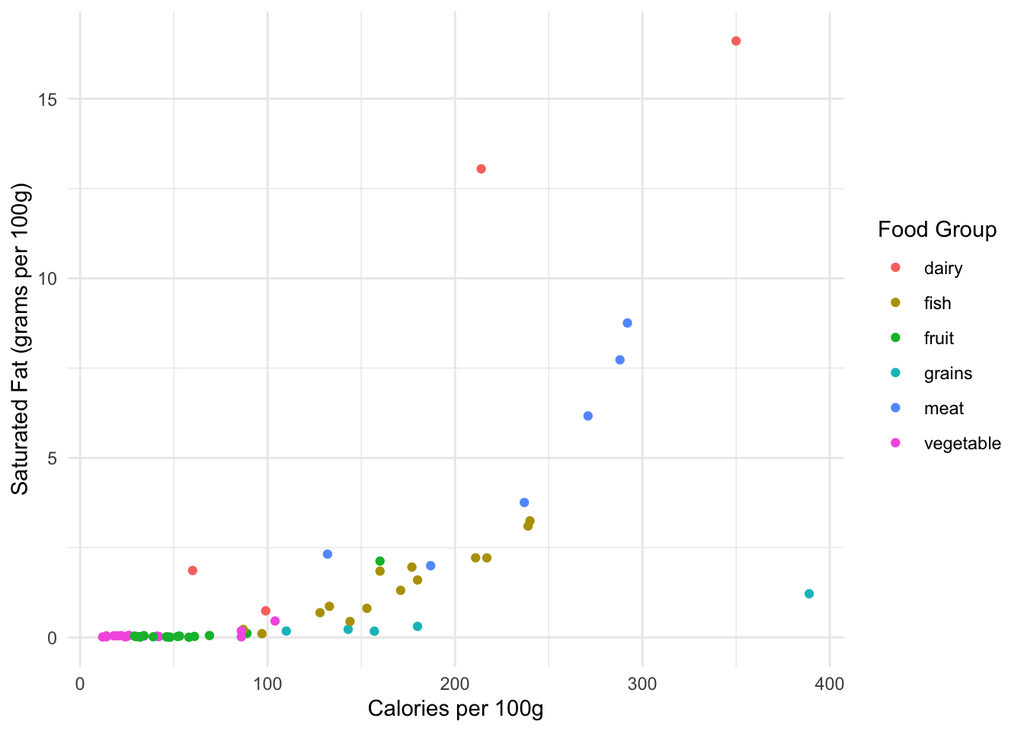

```r
food %>%
  ggplot() +
    geom_point(aes(x = calories, y = sat_fat, color = food_group)) +
    labs(
      x = "Calories per 100g",
      y = "Saturated Fat (grams per 100g)",
      color = "Food Group"
    )
```

Notice that the descriptions inside of the `labs` function is fairly long. The code here breaks it up by putting each argument on its own line (indendent a further two spaces). This is good practice when using functions with a lot of arguments, something we will see throughout this chapter.

We can also had a title (and optional subtitle and caption) to the plot by adding these as named arguments to the `labs` function.

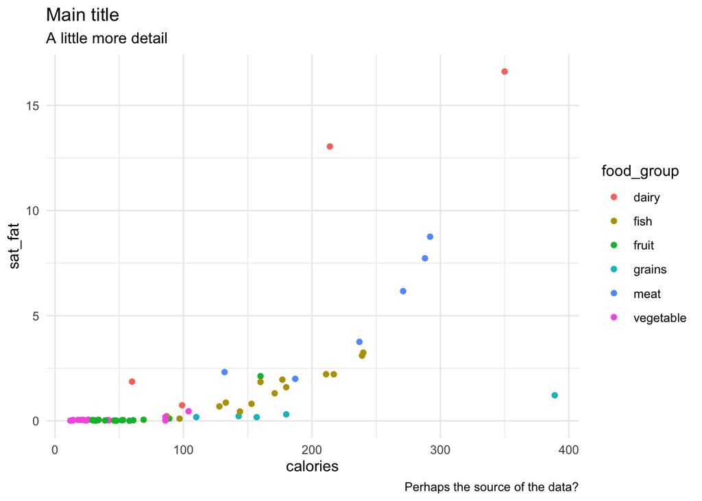

```r
food %>%
  ggplot() +
    geom_point(aes(x = calories, y = sat_fat, color = food_group)) +
    labs(
      title = "Main title",
      subtitle = "A little more detail",
      caption = "Perhaps the source of the data?"
    )
```

Another way to prepare our graphics for publication is to modify the *theme* of a plot. Themes effect the way that the plot elements such as the axis labels, ticks, and background look. By default through this book, we have set the default plot to `theme_minimal`. I think that this is a great choice for exploration of a dataset. As the name implies, it removes most of the clutter of other choices while keeping grid lines and other visual cues to help interpret a dataset. When presenting information for external publication, I prefer to use the theme called `theme_sm` based on the work of Edward Tufte. To set the theme, just call the following line of code sometime before making your plot:

```r
theme_set(theme_sm())
```

Now, when we construct a plot it will use the newly assigned theme:

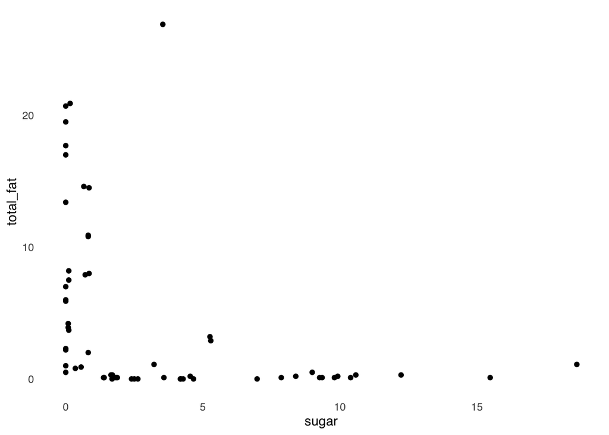

```r
food %>%
  ggplot() +
    geom_point(aes(x = sugar, y = total_fat))
```

The Tufte theme is designed to use as little “ink” as possible, thus focusing the reader on the data. It can be a bit too minimal when first exploring the dataset, but is a great tool for presenting your results.

## Focusing attention

As our first plot, let show where the meat food items fall in relationship to the the other food groups on a plot of calories and total fat.

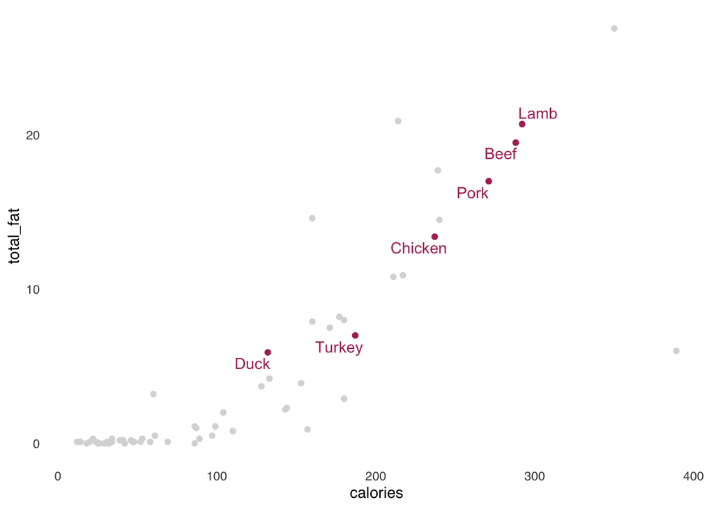

```r
food %>%
  ggplot(aes(calories, total_fat)) +
    geom_point(color = "grey85") +
    geom_point(
      color = "maroon",
      data = filter(food, food_group %in% c("meat"))
    ) +
    geom_text_repel(
      aes(label = item),
      color = "maroon",
      data = filter(food, food_group %in% c("meat"))
    )
```

The same approach works for showing a region of a line plot. Here, we highlight the time between the end of World War I and the onset of World War II.

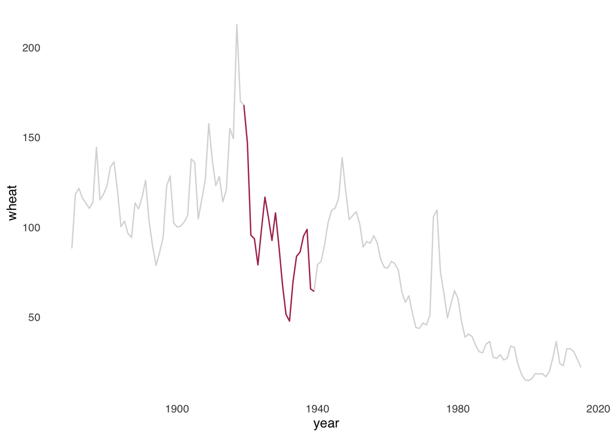

```r
food_prices %>%
  ggplot(aes(year, wheat)) +
    geom_line(color = "grey85") +
    geom_line(
      color = "maroon",
      data = filter(food_prices, between(year, 1919, 1939))
    )
```

If we want to highlight a subset of a plot that required summarization, it is easiest to first create a temporary dataset with the entire summary. Then we can plot the entire dataset in one layer, and subset our call-out in another layer. Here, we will show the average number of calories in various food groups, calling attention to the fruit and vegetable categories.

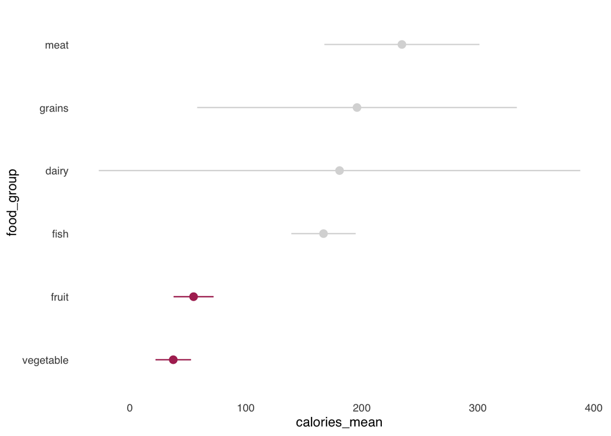

```r
dt <- food %>%
  group_by(food_group) %>%
  summarize(sm_mean_cl_normal(calories)) %>%
  arrange(calories_mean) %>%
  mutate(food_group = fct_inorder(food_group))

dt %>%
  ggplot(aes(food_group, calories_mean, ymin = calories_ci_min, ymax = calories_ci_max)) +
    geom_pointrange(color = "grey85") +
    geom_pointrange(
      color = "maroon",
      data = filter(dt, food_group %in% c("fruit", "vegetable"))
    ) +
    coord_flip()
```

Similarly, we can highlight particular bars within a bar plot by first creating a temporary dataset and then creating two layers from it. Here we highlight the large number of fruits and vegetables present in the dataset relative to the other food groups.

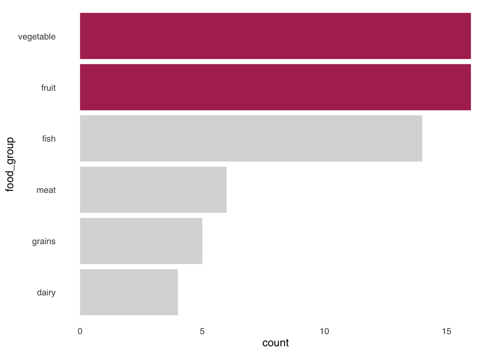

```r
dt <- food %>%
  group_by(food_group) %>%
  summarize(sm_count()) %>%
  arrange(count) %>%
  mutate(food_group = fct_inorder(food_group))

dt %>%
  ggplot(aes(food_group, count)) +
    geom_col(fill = "grey85") +
    geom_col(
      fill = "maroon",
      data = filter(dt, food_group %in% c("fruit", "vegetable"))
    ) +
    coord_flip()
```

Sometimes highlighting with color is used to focus attention on a model in relationship to data, rather than between two subsets of data. Here, we highlight the linear regression line showing the relationship between saturated fat and total fat. We turn off the standard error (`se = FALSE`) bars to avoid cluttering the plot.

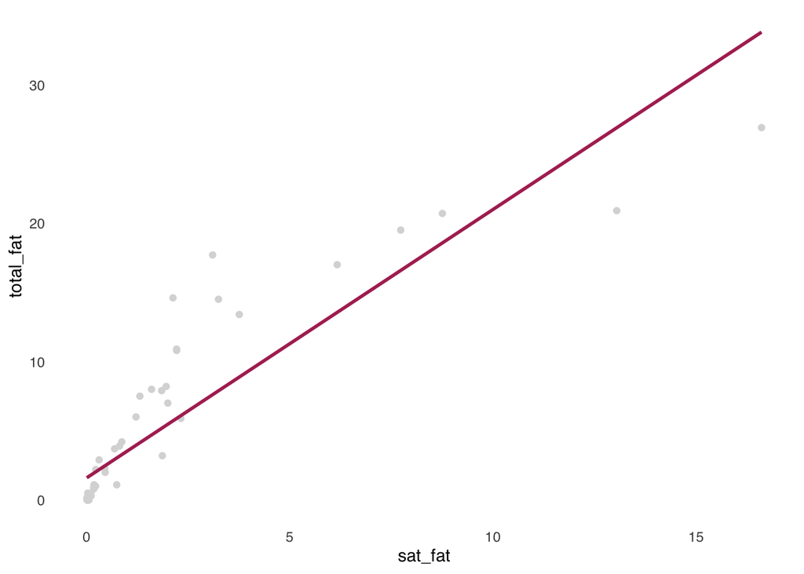

```r
food %>%
  ggplot(aes(sat_fat, total_fat)) +
    geom_point(color = "grey85") +
    geom_smooth(color = "maroon", method = "lm", se = FALSE)
```

It is possible to include multiple colors to show different subsets of the data, but in generally including too many subsets in one plot defeats the purpose of focusing your audience’s attention on one particular part of the plot. I recommend using at most two highlight colors, and only then when they are visually seperated within the plot. An example is shown in the next section.

## Example

Let’s put together all of the elements in this chapter to produce a plot of wheat prices that highlights the differences in prices following WWI and following WWII. We will add a complete set of titles and captions. I selected the second color by picking the complementary color of the maroon used for the first time period.

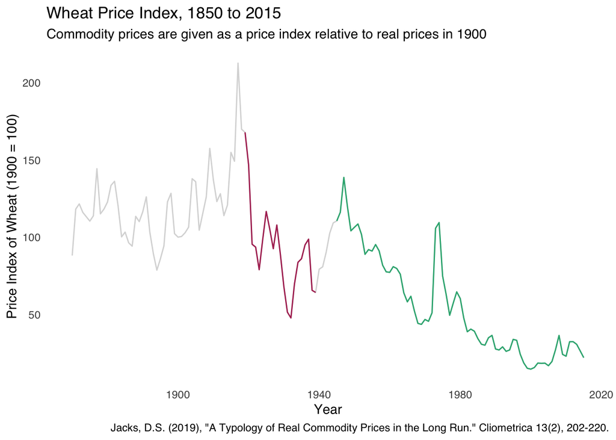

```r
food_prices %>%
  ggplot(aes(year, wheat)) +
    geom_line(color = "grey85") +
    geom_line(
      color = "maroon",
      data = filter(food_prices, between(year, 1919, 1939))
    ) +
    geom_line(
      color = "#30b080",
      data = filter(food_prices, between(year, 1945, 2015))
    ) +
    labs(
      title = "Wheat Price Index, 1850 to 2015",
      subtitle = "Commodity prices are given as a price index relative to real prices in 1900",
      caption = "Jacks, D.S. (2019), \"A Typology of Real Commodity Prices in the Long Run.\" Cliometrica 13(2), 202-220.",
      x = "Year",
      y = "Price Index of Wheat (1900 = 100)"
    )
```

To finish the plot off, and make it look particularly professional, it would be nice to add annotations explaining the main points that you want your audience to take-away from the plot. It is possible to do this directly in R with **ggplot2** annotations, but I find these somewhat awkward and time consuming. A better solution is to open the figure in another program such as Microsoft PowerPoint or the macOS Finder. Here is a plot I made by adding text labels and an arrow to the plot using the macOS Finder application:

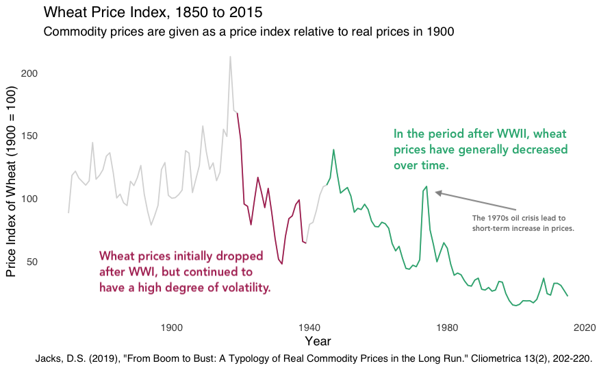

Notice that the plot both shows all of the data for the viewer, but guides them to the specific points of interest that we are interested. The subpoint explaining the peak int he 1970s is shown in a smaller font size, and in a dark grey, because it is secondary to the points I wanted to make about the overall trends in the two post-war periods.

## Exercises and References

There is are two exercise notebooks for this chapter:

- **exercies07A.Rmd**: prompts for producing presentation-ready plots from various datasets
- **exercies07B.Rmd**: open-ended questions to explore with data

It is strongly recommended to complete at least the first notebook prior to continuing on to the next chapter.